# Stat542: Simulation Study with Boston Housing Data

```r
library(glmnet)  # glmnet for lasso
library(ggplot2)  # qplot
library(gridExtra)  # grid.arrange,
```

#### Boston Housing Data 1

The original data is from the R library `mlbench`, which has 506 observations on 19 variables. We apply some suggested transformations on the data (same as what we did before), remove three variables medv, town, and tract, and use cmedv as theresponse variable $Y$.

Load `BostonHousing1.Rdata`, which has 16 variables including the response variable $Y$. We try the following TEN methods:

1. A linear regression model using all features
2. Forward/backward selection with AIC
3. Forward/backward selection with BIC
4. Ridge regression using lambda.min or lambda.1se
5. Lasso using lambda.min or lambda.1se, or lambda.1se with refit

We repeat the following simulation 50 times. In each iteration, randomly split the data into two parts, 75% for training and 25% for testing. Fit the model based on the training data and obtain a prediction on the test data, record the mean squared prediction error (MSPE) on the test set, the selected model-size or effect dimension (for Ridge), and the computation time for each procedure.

- Load the data and parepare for the simulation.

```r
rm(list = ls())  # remove the objects in R before loading the new data
load('BostonHousing1.Rdata')
myData = Housing1
n = nrow(myData)
p = ncol(myData) - 1

# some algorithms need the matrix/vector
# input (instead of a data frame)
X = data.matrix(myData[,-1])
Y = myData[,1]
```

Suggest to set up the following matrices to save the output

- Tx10 matrix for MSPE
- Tx10 matrix for model size
- 10x1 for running time

Suggest to save the row IDs for test data for all T iterations, so can use the same training/test split for each method.

```r
# all.test.id: ntestxT matrix, each column records
ntest = round(n * 0.25)  # test set size
ntrain = n-ntest  # training set size
all.test.id = matrix(0, ntest, T)  #
for(t in 1:T){
  all.test.id[, t] = sample(1:n, ntest)
}
save(all.test.id, file="alltestID.RData")

test.id = all.test.id[,1]
```

#### List of Methods

- Method 1: Full Model (Full)

```r
start.time = proc.time()
full.model = lm(Y ~ ., data = myData[-test.id,])
Ytest.pred = predict(full.model, newdata = myData[test.id,])
mean((Y[test.id] - Ytest.pred)^2)
proc.time() - start.time
```

- Method 2: Forward AIC (AIC.F)

```r
start.time = proc.time()
full.model = lm(Y ~ ., data = myData[-test.id, ])
stepAIC = step(lm(Y ~ 1, data = myData[-test.id, ]),
                 list(upper = full.model),
                 trace = 0, direction = "forward")
Ytest.pred = predict(stepAIC, newdata = myData[test.id, ])

# number of predictors (excluding the intercept)
length(stepAIC$coef) - 1
proc.time() - start.time
```

- Method 3: Backward AIC (AIC.B)

```r
start.time = proc.time()
full.model = lm(Y ~ ., data = myData[-test.id, ])
stepAIC = step(full.model, trace = 0, direction = "backward")
Ytest.pred = predict(stepAIC, newdata = myData[test.id, ])
length(stepAIC$coef) - 1
proc.time() - start.time
```

- Method 4: Forward BIC (BIC.F)

```r
start.time = proc.time()
full.model = lm(Y ~ ., data = myData[-test.id, ])
stepAIC = step(lm(Y ~ 1, data = myData[-test.id, ]),
               list(upper = full.model),
               trace = 0, direction = "forward", k = log(ntrain))
Ytest.pred = predict(stepAIC, newdata = myData[test.id, ])

# number of predictors (excluding the intercept)
length(stepAIC$coef) - 1
proc.time() - start.time
```

- Method 5: Backward BIC (BIC.B)

```r
start.time = proc.time()
full.model = lm(Y ~ ., data = myData[-test.id, ])
stepAIC = step(full.model, trace = 0,
               direction = "backward", k = log(ntrain))
Ytest.pred = predict(stepAIC, newdata = myData[test.id, ])
length(stepAIC$coef) - 1
proc.time() - start.time
```

- Method 6/7: Ridge with lambda_min/lambda_1se (R_min, R_1se)

```r
start.time = proc.time()
cv.out = cv.glmnet(X[-test.id, ], Y[-test.id], alpha = 0)
best.lam = cv.out$lambda.min
Ytest.pred = predict(cv.out, s = best.lam, newx = X[test.id, ])
proc.time() - start.time
# Exclude the computation for DF when recording computing time for Ridge,

# DF for Ridge
# DF = tr(S) where S = X(X^t X + lam*I)^{-1}X^t and X is the standardized design
# matrix with each column having mean zero and sd 1. Note that glmnet computes
# sd using denominator n not (n-1).
# In addition, the objective function in glmnet for ridge is slightly different
# from the one used in class. So lam used in S (above) corresponds to lambda.min
# or lambda.1se times the sample size

ntrain = n - dim(all.test.id)[1]
tmpX = scale(X[-test.id, ]) * sqrt(ntrain / (ntrain - 1))
d = svd(tmpX)$d

# df for Ridge with lambda_min
best.lam = cv.out$lambda.min
sum(d^2/(d^2 + best.lam*ntrain))

# df for Ridge with lambda_1se
best.lam = cv.out$lambda.1se
sum(d^2/(d^2 + best.lam*ntrain))
```

- Method 8: Lasso using lambda.min (L_min)

```r
cv.out = cv.glmnet(X[-test.id, ], Y[-test.id], alpha = 1)
best.lam = cv.out$lambda.min
Ytest.pred = predict(cv.out, s = best.lam, newx = X[test.id, ])
mean((Ytest.pred - Y[test.id])^2)
mylasso.coef = predict(cv.out, s = best.lam, type = "coefficients")
sum(mylasso.coef != 0) - 1  # size of Lasso with lambda.min
```

- Method 9/10: Lasso using lambda.1se without/with Refit (L_1se, L_Refit)

```r
cv.out = cv.glmnet(X[-test.id, ], Y[-test.id], alpha = 1)
best.lam = cv.out$lambda.1se
Ytest.pred = predict(cv.out, s = best.lam, newx = X[test.id, ])
mean((Ytest.pred - Y[test.id])^2)
mylasso.coef = predict(cv.out, s = best.lam, type = "coefficients")
sum(mylasso.coef != 0) - 1 # size of Lasso with lambda.1se

var.sel = row.names(mylasso.coef)[nonzeroCoef(mylasso.coef)[-1]]
tmp.X = X[, colnames(X) %in% var.sel]
mylasso.refit = coef(lm(Y[-test.id] ~ tmp.X[-test.id, ]))
Ytest.pred = mylasso.refit[1] + tmp.X[test.id,] %*% mylasso.refit[-1]
mean((Ytest.pred - Y[test.id])^2)
```

#### Tuning

The default ranges for ridge or lasso may not to be the best. Here is what we suggest students to do:

- run T=50 iterations of ridge using the default lambda choice, record the range of lambda (i.e., the min and max of lambda values), and record lambda.min and lambda.1se.
- display the lambda values in log-scale (by default, lambda’s are equally spaced in log-scale in glmnet) in a matrix of T-by-4 columns (cols 1 and 2: min and max of candidate lambda values; col 3: lambda.min; col 4: lambda.1se). Check whether lambda.min or lambda.1se hit the boundary of the candiate lambda values (e.g., lambda.min gets close to the minimal choice of lambda).
- Based on the previous result, come with a proper choice of sequence of lambda values and run ridge with the provided lambda sequence.
- Do the same for lasso for each data set.

#### Results for Boston Housing 1

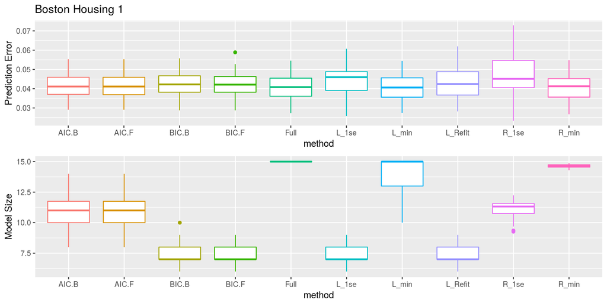

Five-number summary for Prediction error and model size

```r
summary(PSE)
```

```
##       Full             AIC.F             AIC.B             BIC.F
##  Min.   :0.02733   Min.   :0.02906   Min.   :0.02906   Min.   :0.02878
##  1st Qu.:0.03609   1st Qu.:0.03690   1st Qu.:0.03706   1st Qu.:0.03819
##  Median :0.04081   Median :0.04114   Median :0.04114   Median :0.04212
##  Mean   :0.04075   Mean   :0.04149   Mean   :0.04151   Mean   :0.04218
##  3rd Qu.:0.04548   3rd Qu.:0.04592   3rd Qu.:0.04592   3rd Qu.:0.04630
##  Max.   :0.05453   Max.   :0.05529   Max.   :0.05529   Max.   :0.05887
##      BIC.B             R_min             R_1se             L_min
##  Min.   :0.02878   Min.   :0.02670   Min.   :0.02338   Min.   :0.02740
##  1st Qu.:0.03819   1st Qu.:0.03564   1st Qu.:0.04057   1st Qu.:0.03560
##  Median :0.04222   Median :0.04127   Median :0.04511   Median :0.04061
##  Mean   :0.04211   Mean   :0.04094   Mean   :0.04676   Mean   :0.04092
##  3rd Qu.:0.04670   3rd Qu.:0.04522   3rd Qu.:0.05468   3rd Qu.:0.04563
##  Max.   :0.05577   Max.   :0.05480   Max.   :0.07289   Max.   :0.05444
##      L_1se            L_Refit
##  Min.   :0.02580   Min.   :0.02821
##  1st Qu.:0.03910   1st Qu.:0.03672
##  Median :0.04598   Median :0.04242
##  Mean   :0.04505   Mean   :0.04306
##  3rd Qu.:0.04884   3rd Qu.:0.04880
##  Max.   :0.06073   Max.   :0.06196
```

```r
summary(mSize)
```

```
##       Full        AIC.F           AIC.B           BIC.F
##  Min.   :15   Min.   : 8.00   Min.   : 8.00   Min.   :6.00
##  1st Qu.:15   1st Qu.:10.00   1st Qu.:10.00   1st Qu.:7.00
##  Median :15   Median :11.00   Median :11.00   Median :7.00
##  Mean   :15   Mean   :10.72   Mean   :10.80   Mean   :7.46
##  3rd Qu.:15   3rd Qu.:11.75   3rd Qu.:11.75   3rd Qu.:8.00
##  Max.   :15   Max.   :14.00   Max.   :14.00   Max.   :9.00
##      BIC.B           R_min           R_1se            L_min
##  Min.   : 6.00   Min.   :14.30   Min.   : 9.264   Min.   :10.00
##  1st Qu.: 7.00   1st Qu.:14.55   1st Qu.:10.747   1st Qu.:13.00
##  Median : 7.00   Median :14.65   Median :11.320   Median :15.00
##  Mean   : 7.52   Mean   :14.63   Mean   :11.106   Mean   :13.98
##  3rd Qu.: 8.00   3rd Qu.:14.74   3rd Qu.:11.561   3rd Qu.:15.00
##  Max.   :10.00   Max.   :14.87   Max.   :12.234   Max.   :15.00
##      L_1se         L_Refit
##  Min.   :6.00   Min.   :6.00
##  1st Qu.:7.00   1st Qu.:7.00
##  Median :7.00   Median :7.00
##  Mean   :7.22   Mean   :7.22
##  3rd Qu.:8.00   3rd Qu.:8.00
##  Max.   :9.00   Max.   :9.00
```

Report running time

```r
rTime
```

```
##    Full   AIC.F   AIC.B   BIC.F   BIC.B   R_min   R_1se   L_min   L_1se
##   0.192   5.360   7.504   3.800   3.016   4.512   4.280   4.428   4.988
## L_Refit
##   4.388
```

#### Results for Boston Housing 2

`BostonHousing2.Rdata` has 135 variables including: (1) the response variable $Y$, (2) the original 15 predictors in Boston Housing Data 1, (3) their quadratic terms (14) and all pairwise interaction terms (105).

For such $p = 134$, even forward/backward AIC/BIC is slow. So we only compare 5 methods:

- Ridge with lambda_min/lambda_1se (R_min, R_1se)
- Lasso with lambda_min/lambda_1se (L_min, L_1se)
- Lasso with lambda_1se and Refit (L_Refit)

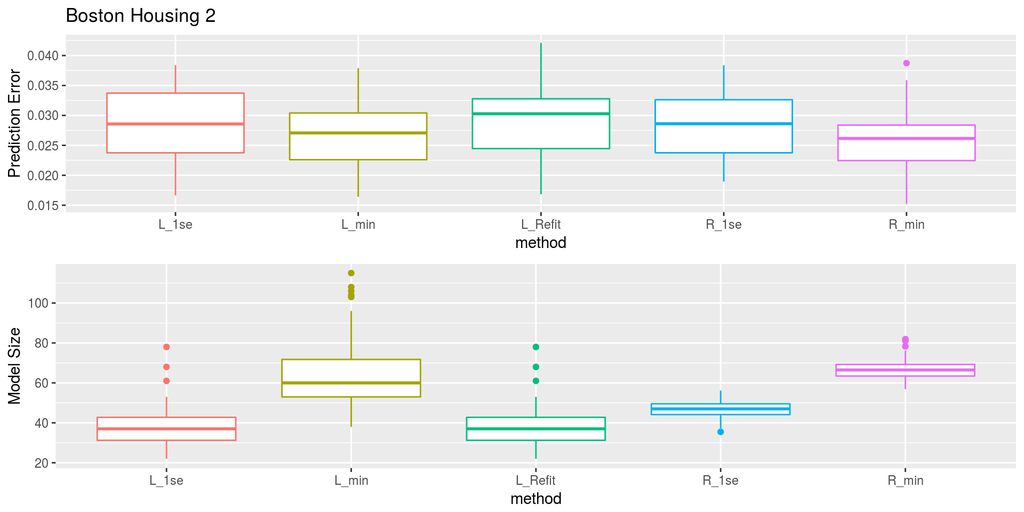

Five-number summary for Prediction error and model size

```r
summary(PSE)
```

```
##      R_min             R_1se             L_min             L_1se
##  Min.   :0.01520   Min.   :0.01895   Min.   :0.01641   Min.   :0.01663
##  1st Qu.:0.02245   1st Qu.:0.02376   1st Qu.:0.02261   1st Qu.:0.02376
##  Median :0.02615   Median :0.02862   Median :0.02708   Median :0.02857
##  Mean   :0.02571   Mean   :0.02849   Mean   :0.02665   Mean   :0.02850
##  3rd Qu.:0.02839   3rd Qu.:0.03262   3rd Qu.:0.03040   3rd Qu.:0.03373
##  Max.   :0.03873   Max.   :0.03838   Max.   :0.03789   Max.   :0.03840
##     L_Refit
##  Min.   :0.01684
##  1st Qu.:0.02446
##  Median :0.03027
##  Mean   :0.02923
##  3rd Qu.:0.03278
##  Max.   :0.04213
```

```r
summary(mSize)
```

```
##      R_min           R_1se           L_min            L_1se
##  Min.   :56.90   Min.   :35.49   Min.   : 38.00   Min.   :22.00
##  1st Qu.:63.45   1st Qu.:44.15   1st Qu.: 53.00   1st Qu.:31.25
##  Median :66.48   Median :47.00   Median : 60.00   Median :37.00
##  Mean   :67.07   Mean   :46.58   Mean   : 65.64   Mean   :38.36
##  3rd Qu.:69.27   3rd Qu.:49.54   3rd Qu.: 71.75   3rd Qu.:42.75
##  Max.   :81.93   Max.   :56.17   Max.   :115.00   Max.   :78.00
##     L_Refit
##  Min.   :22.00
##  1st Qu.:31.25
##  Median :37.00
##  Mean   :38.36
##  3rd Qu.:42.75
##  Max.   :78.00
```

Report running time

```r
rTime
```

```
##   R_min   R_1se   L_min   L_1se L_Refit
##  54.492  53.868  76.216  77.584  76.672
```

#### Results for Boston Housing 3

`BostonHousing3.Rdata` has 635 variables including: (1) the response variable $Y$, (2) the predictors in Boston Housing Data 2, and (3) 500 noise features.

In our simulation studies, we only compare 5 methods due to large size of $p$

- Ridge with lambda_min/lambda_1se (R_min, R_1se)
- Lasso with lambda_min/lambda_1se (L_min, L_1se)
- Lasso with lambda_1se and Refit (L_Refit)

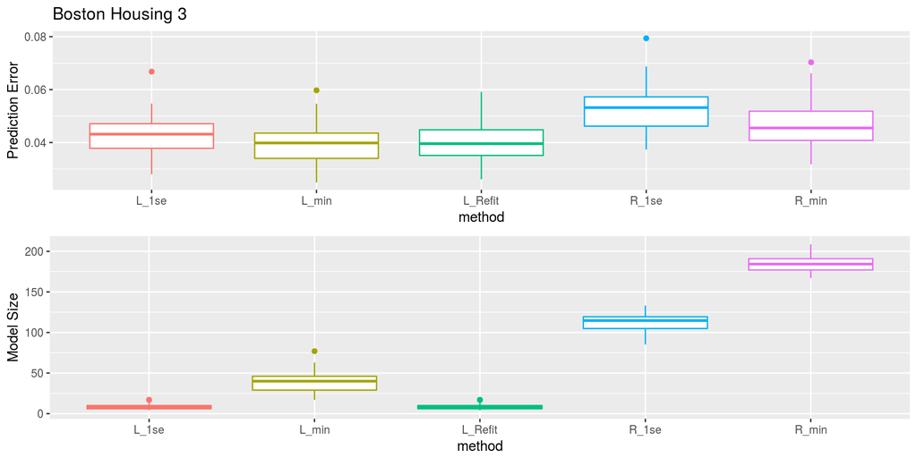

Five-number summary for Prediction error and model size

```r
summary(PSE)
```

```
##      R_min             R_1se             L_min             L_1se
##  Min.   :0.03180   Min.   :0.03735   Min.   :0.02490   Min.   :0.02800
##  1st Qu.:0.04083   1st Qu.:0.04619   1st Qu.:0.03402   1st Qu.:0.03782
##  Median :0.04551   Median :0.05320   Median :0.03985   Median :0.04316
##  Mean   :0.04700   Mean   :0.05240   Mean   :0.03910   Mean   :0.04326
##  3rd Qu.:0.05185   3rd Qu.:0.05727   3rd Qu.:0.04356   3rd Qu.:0.04712
##  Max.   :0.07033   Max.   :0.07940   Max.   :0.05975   Max.   :0.06680
##     L_Refit
##  Min.   :0.02610
##  1st Qu.:0.03513
##  Median :0.03958
##  Mean   :0.04045
##  3rd Qu.:0.04481
##  Max.   :0.05918
```

```r
summary(mSize)
```

```
##      R_min           R_1se            L_min           L_1se
##  Min.   :167.1   Min.   : 85.14   Min.   :17.00   Min.   : 4.00
##  1st Qu.:177.0   1st Qu.:104.91   1st Qu.:29.00   1st Qu.: 6.00
##  Median :184.3   Median :114.72   Median :40.00   Median : 8.00
##  Mean   :184.0   Mean   :113.02   Mean   :38.92   Mean   : 8.36
##  3rd Qu.:190.9   3rd Qu.:119.39   3rd Qu.:46.00   3rd Qu.:10.00
##  Max.   :208.7   Max.   :133.24   Max.   :77.00   Max.   :17.00
##     L_Refit
##  Min.   : 4.00
##  1st Qu.: 6.00
##  Median : 8.00
##  Mean   : 8.36
##  3rd Qu.:10.00
##  Max.   :17.00
```

Report running time

```r
rTime
```

```
##   R_min   R_1se   L_min   L_1se L_Refit
## 102.928 104.120  83.852  84.488  83.776
```